# **SPSS Üzerinde Betimleyici İstatistiklerin Hesaplanması**

### Şartlı Seçim (Conditional Select) Uygulaması

**Select Cases**

Belirli bir özelliğe uyan birimlerin seçilmesini sağlar. Belirli bir kritere göre aynı özelliklere sahip birimleri diğerlerinden ayırarak işlemlere almayı sağlayan bir seçenektir.

Menü yoluyla:

***Data > Select Case***

[figure not shown]

**Uygulama**

Örnek olarak okuma skoru (reading score) için 60 geçme skoru puanı olsun ve bu skoru geçen öğrencileri filtreleyelim.

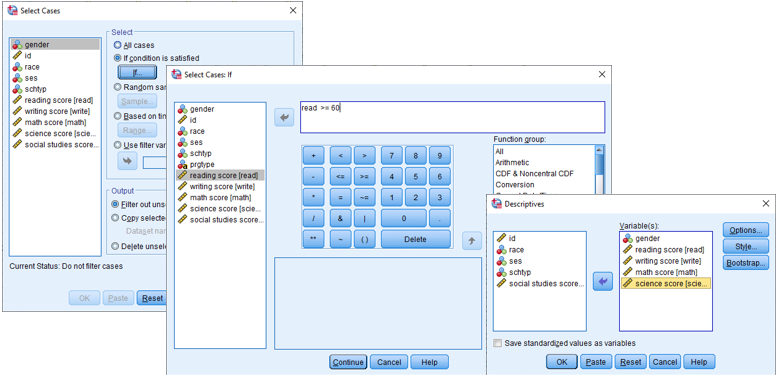

Artık yapacağımız bütün çalışmalarda okuma skoru değişkeni için 60 ve üzeri olan değerler alınacaktır. Örnek olarak bu değişkenin betimleyici istatistiklerini inceleyelim.

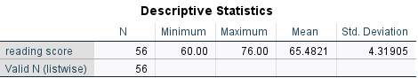

Bu tip filtreleme kullanıldıktan sonra aynı menü üzerinden **All Cases** seçeneği kullanılıp veri üzerindeki filtre kaldırılmalıdır.

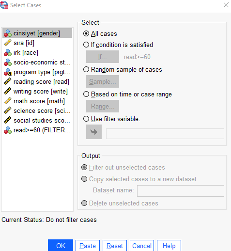

### Şartlı Seçim (Conditional Select - String) Uygulaması

**Select Cases**

Örnek olarak string tipinde okul tipini görmek için filtreleyelim.

Menü yoluyla:

***Data > Select Case***

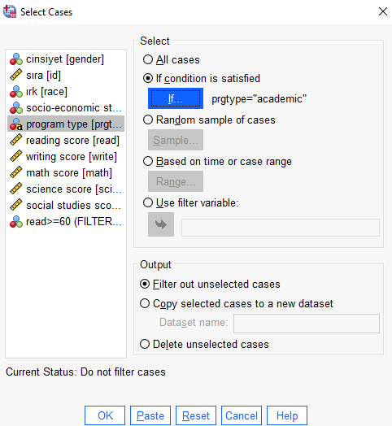

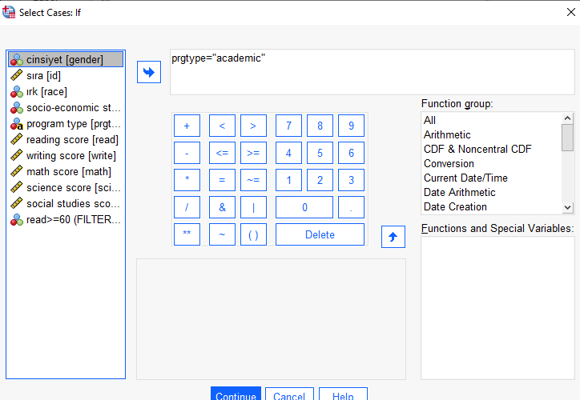

Artık yapacağımız bütün çalışmalarda **program tipi** için sadece ***academic*** kategorisi alınacaktır. Örnek olarak bu değişkenin betimleyici istatistiklerini inceleyelim.

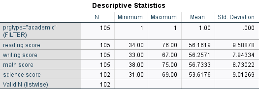

### Şartlı Seçim (Conditional Select - Range) Uygulaması

**Select Cases**

Örnek olarak ilk 40 veriyi range seçeneğini kullanarak filtreleyelim.

Menü yoluyla:

***Data > Select Case***

Veriyi 1-40 aralığında filtreledikten sonra SPSS **Data View** kısmında aşağıdaki şekilde görünecektir.

[figure not shown]

### Transform Menüsü

Veri dosyasının ana yapısını değiştirmeden veri değerleri üzerinde ihtiyac duyulan bazı dönüştürmeleri yapar.

Veri üzerinde kök alma, kübik hale getirme, log haline getirme ve matematiksel işlemler gibi noktalarda kullanılır.

Bu menüde en çok kullanılan seçenekler uygulamalı olarak gösterilecektir.

**Compute Variable**

Bazı durumlarda mevcut değişken değerlerini çeşitli matematiksel ya da mantıksal işlemlere tabi tutularak, bunlardan yeni değişken tanımlama ve yeni değişken değerlerinin hesaplanması gerekebilir. SPSS’de bu işlemleri yapabilme seçenekleri ve imkânı vardır. Uygulanan matematiksel işlem sonucu elde edilen yeni değerler, araştırmacı tarafından tanımlanan farklı bir değişkene (***Target Variable***) atanır. Tanımlanan yeni değişken ve değerleri* *Data View** sayfasında farklı bir sütunda görüntülenir. Bu işlemler için işlem algoritması aşağıdaki gibi uygulanır.

Bu seçenek veri setinde yeralan değişkenlerden belirli bir cebirsel (trigonometrik, aritmetik ve mantıksal fonksiyon) kritere göre tüm birimler için yeni değişkenler belirlemeyi sağlar. Bu seçenek tıklandığında aşağıdaki ekran görüntülenir ve ekrana girişler yapılır.

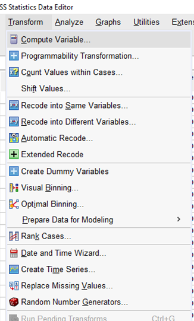

**Örnek**

Okuma skoru (read) değişkeninin kareakökünü alalım ve karekökü alınmış değişkeni yeni bir değişken olarak tanımlayalım. Yeni değişken **Data View** kısmı üzerinde oluşacaktır.

Bu yeni değişkenimize ***new_read*** ismini pencerede **Target Variable** bölümüne yazalım.

Daha sonra **Numeric Expression** kısmına yapmak istediğmiz düzenlemeye dair formülü girelim.

Burada karekökü alma ***SQRT()*** formülü ile gerçekleştirilir.

Bu ve diğer bütün seçeneklere **Function group:** bölmesi üzerinden de erişebilirsiniz.

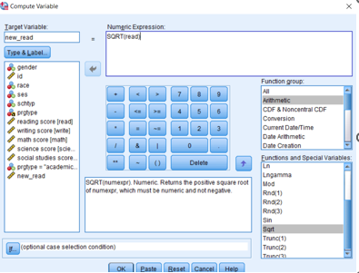

**Örnek**

Bernoulli dağılımını (dağılım parametre değeri = 0.5) kullanarak rastgele sayılar üretelim ve ismi ***new_read1** olarak veritabanımıza eklensin.

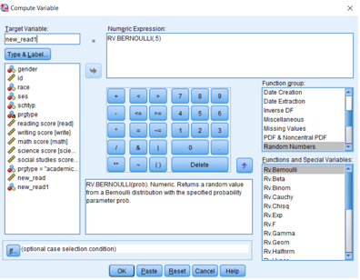

**Recode Into Different Variables (Kategorik)**

Recode Into Different Variables iletişim kutusu, mevcut değişkenlerin değerlerini yeniden atamanıza veya mevcut değer aralıklarını yeni bir değişken için yeni değerlere daraltmanıza olanak tanır. Örneğin maaşları, maaş aralığı kategorilerini içeren yeni bir değişkene daraltabilirsiniz.

Sayısal ve dize (string) değişkenlerini yeniden kodlayabilirsiniz. Sayısal değişkenleri dize değişkenlerine (veya tam tersi) yeniden kodlayabilirsiniz.

Eğer birden fazla değişken seçerseniz hepsinin aynı türde olması gerekir. Sayısal ve dize (string) değişkenlerini birlikte yeniden kodlayamazsınız.

**Recode** iki alt menüden oluşmaktadır.

- ***Into Same Variables***: Kayıtlı değerlerin kodlanmasını sağlar. Bir değişkenin belirlenen aralıktaki değerlerini yeni kod değerleri ile* **aynı*** isim altında veri sayfasına yazmaya yarar.
- ***Into Different Variables***: Kayıtlı değerlerin kodlanmasını sağlar. Bir değişkenin belirlenen aralıktaki değerlerini yeni kod değerleri ile* **farklı*** bir değişken ismi altında veri sayfasına yazmaya yarar.

[figure not shown]

**Örnek**

Yeni Değişkenler İçin Yeniden Kodlanacak Değerleri Belirleme

1. Menü yoluyla:

***Transform > Recode into Different Variables...***

1. Yeniden kodlamak istediğiniz değişkenleri seçin. Birden fazla değişken seçerseniz bunların aynı türde (sayısal veya dize) olması gerekir.
2. Her yeni değişken için bir çıktı (yeni) değişken adı girin ve ***Change***'e tıklayın.
3. ***Old and New Values**'e tıklayın.
4. Eski değeri ve yeni olmasını istediğiniz değeri belirtin.
5. Eski ve yeni değişimini yapmak için ***Old–>New*** listesine yerleştirmek için ***Add*** seçeneğini tıklayın.

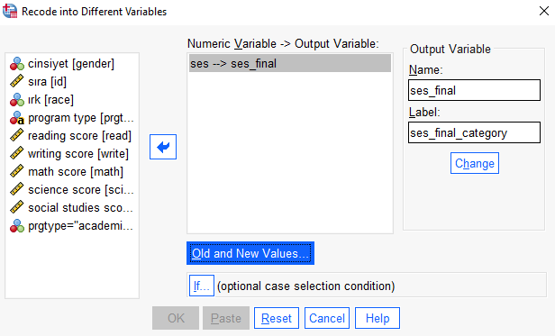

***Old and New Values** üzerinden kategori numara değişimlerini yapalım.

1 (***old value***) olan kategori sınıfını 3 (***new value***) yapalım ve* **Add*** seçeneği ile diyalog kutusuna ekleyelim. Yani yüksek sosyo-ekonomik sınıf ile düşük sosyo-ekonomik sınıf değerlerini değiştirelim.

3 olan kategori sınıfını da aynı işlemleri yaparak 1 yapalım ve ***Continue*** ile işlemi tamamlayalım.

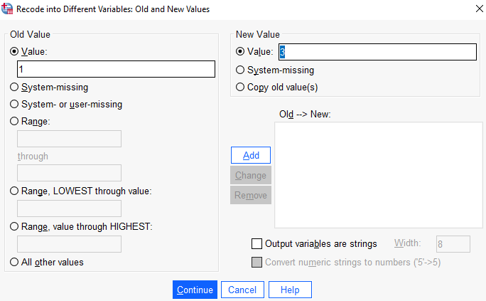

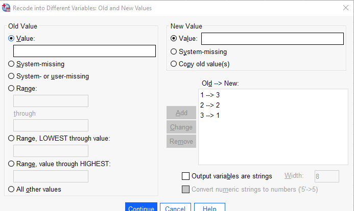

Daha sonra yeni oluşan değişkenin alt kategorileri SPSS ana sayfasında **Variable view** kısmından ***Values*** seçeneği ile tanımlanır.

**Automatic Recode**

Bir değişkenin değerlerini büyüklük sırasına göre dizerek yeni bir değişkene birden başlayarak yeni değerlerle kodlayarak yazar. Yeni değişken sınıflandırıldığında orjinal değerlerde tabloda görüntülenir.

Menü yoluyla:

[figure not shown]

***Read*** değişkenimizi autorecode ile yeni bir değişken haline getirelim ve yeni ismi ***read_autorecode*** olsun.

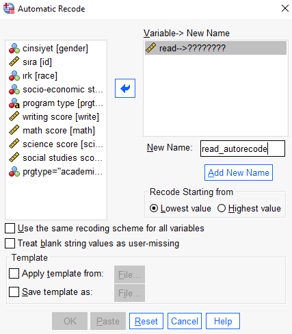

***Add New Name*** tıklayarak ekleyelim ve ***OK*** 'e tıklayarak işlemi tamamlayalım. Daha sonra tanımladığımız veri **Data View** ksımında görünecektir.

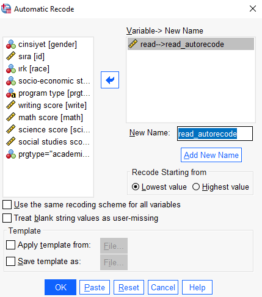

## Yeni Değişken Oluşturma

***Transform > Compute Variable** seçeneğini kullanarak yeni bir değişken oluşturalım.

Bu değişken ***reading, writing ve math*** skorlarının toplamından oluşsun ve ismini ***total*** olarak belirleyelim.

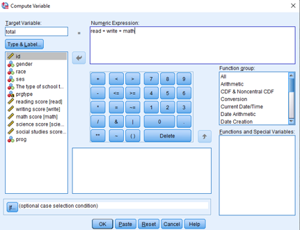

**Recode Into Different Variables (Range kullanarak)**

Bu uygulamayı daha önce oluşturduğumuz total değişkeni üzerinden işleme sokalım.

**Örnek** Total değişkeni için aşağıdaki aralıkları kullanarak değişken tanımlamalarını yapınız ve değişken kategorilerini atayalım.

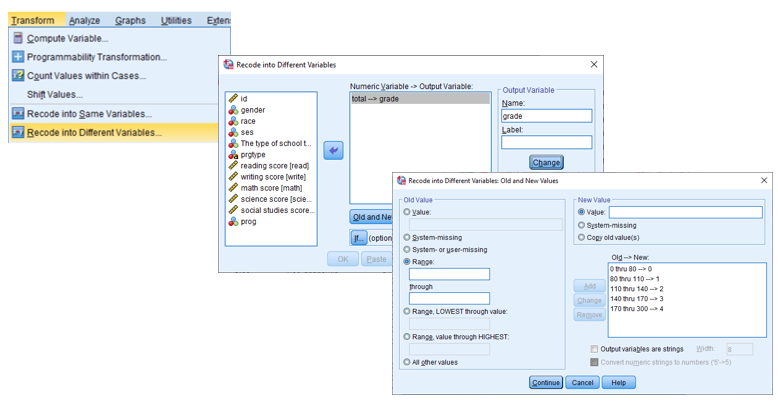

Değişken kategorilerini SPSS anasayfasında **Variable View** kısmında ***Values*** sütununda atanması gereklidir.

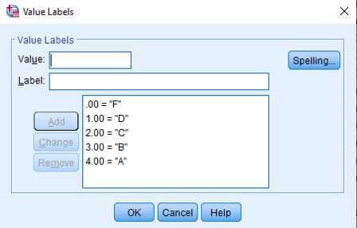

## ÇAPRAZ TABLOLARIN OLUŞTURULMASI

Veri setlerinde yer alan değişkenlerin frekans dağılım tablolarının ya da çapraz tablolarının hazırlanması, verilerin özetlenmesi bakımından önem taşımaktadır.

Çapraz tablolar, iki değişkenin karşılıklı alt seçeneklerini birlikte gösteren tabloladır. $r*c$ biçimindeki (r=sıra sayısı ve c=sütun sayısı) çapraz tabloların veri sayfasına girilmesinde tablonun sıra ve sütun sayısı dikkate alınarak giriş yapılır. İki değişkenin alt sçeneklerine aynı anda sahip olan birim sayıları, çapraz tablonun göze frekanslarını oluşturur. Çapraz tablolar daha çok az sayıda seçenek içeren kategorik değişkenler için ya da sınıflara bölünerek kodlanmış ve k sayıda sınıfa indirgenmiş aralıklı/orantılı ölçekli verilerin gösteriminde yararlanılır.

Her ikisi de nitel türden ya da nicel türden fakat sınıflama veya sıralama düzeyinde ölçülmüş (yani gruplandırılmış frekans verisi), birisi nitel türden diğeri nicel türden fakat sınıflama veya sıralama düzeyinde ölçülmüş (yani gruplandırılmış frekans verisi) olan değişkenlere ait verileri düzenlemede ve bu tür değişkenlerle ilgili uygun olan istatistiksel analizleri gerçekleştirmede çapraz tablolara ihtiyaç duyulmaktadır.

### SPSS’de Çapraz Tablo Oluşturulması

- SPSS veri sayfasında sütunlara uygun girişler yapılır.
- ***Analyze > Descriptive statistics > Crosstabs*** seçenekleri tıklanır.

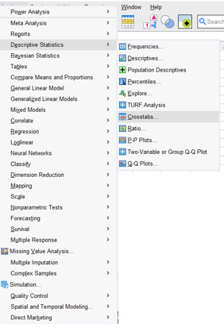

- Açılan bu ekranda değişkenler listesinde yer alan değişkenlerden birisi satır değişkenine (Row(s)), diğeri sütun değişkenine (Column(s)) aktarma butonu yardımı ile aktarılır. ***OK*** butonuna basarak çapraz tablo oluşturulur.

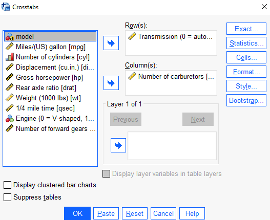

- Elde edilen çıktıdaki tablo bilgileri yanında bazı katsayı ve ölçülerin görüntülenmesi isteniyorsa işlem penceresinde ***Statistics*** seçeneği tıklanır. Bu pencerede çıktıda yer alması istenilen istatistikler ve katsayılar işaretlenir. ***Continue*** tıklanır.

**Çapraz Tablo Çıktısı**

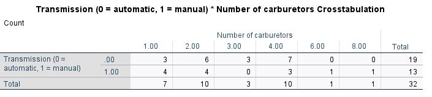

Yukarıdaki çapraz tablo sonuçlarını incelediğimizde:

- Otomatik vitese ve bir adet karbüratöre sahip 3 otomobil modeli vardır.
- Manuel vitese ve bir adet karbüratöre sahip 4 otomobil modeli vardır.
- 4 karbütöre ve otomatik şanzımana sahip 7 otomobil modeli vardır.
- 1 karbüratöre sahip toplam 7 adet (3+4) otomobil modeli vardır.
- Mauel vitese sahip toplam 13 adet (4+4+0+3+1+1) otomobil modeli vardır.
- Toplam (total) olarak 32 adet otomobil vardır.

**Çapraz Tablo Çıktısı (satır, sütun ve toplam yüzdeliklerle)**

Menü yoluyla

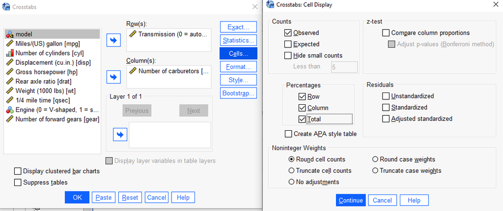

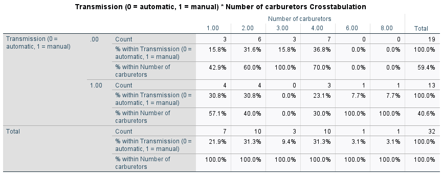